# tme-01

## Implémentation de mesures classiques

### Moyenne

**[Q]** **La moyenne**

Ecrire la fonction moyenne(valeurs) qui calcule la moyenne des éléments d'un tableau (en utilisant la boucle ''for'', sans utiliser les fonctions déjà implémentées dans numpy)

Tester la fonction moyenne et comparer vos résultats avec l'implémentation de base de python donnée ci-dessous:

```python
print("La moyenne (MedQ) est avec ma fonction : %f dollars" % moyenne(prices_pd["MedQ"]))
print("La moyenne (MedQ) est avec mean        : %f dollars" % prices_pd["MedQ"].mean())
```

```
La moyenne (MedQ) est avec ma fonction : 247.618306 dollars
La moyenne (MedQ) est avec mean        : 247.618306 dollars
```

**[Q]** **Moyennes sur les qualités**

Calculer:

- La moyenne des prix pour les qualités medium et high
- La moyenne des prix pour les qualités medium et high dans l'état de ''New York''

Les calculs seront fait d'une part à l'aide de votre fonction, et d'autre part à l'aide des fonctions de python.

```
Moyenne MedQ  :  247.61830603956537
Moyenne HighQ :  329.75985414210226
Moyenne MedQ à NY  :  265.37694877505584
Moyenne HighQ à NY :  346.91276169265035
```

**[Q]** **Moyenne sur les états**

Calculez la moyenne des prix qualités medium et high dans tous les états -- la liste des états est obtenues ainsi states=np.unique(prices_pd["State"].values)

Pour cela, vous pouvez (devez) le faire de deux manières:

- Faire une boucle sur chacun des états
- Utiliser la fonction groupby comme expliqué ici : http://pandas.pydata.org/pandas-docs/stable/groupby.html et ici : https://www.kaggle.com/crawford/python-groupby-tutorial

[output not shown]

**[Q]** **D'autres moyennes**

Calculer la moyenne (avec les deux fonctions) sur le prix de la basse qualité. Que constatez vous ? Expliquez...

**[Q]** **Modification de données**

Remplacez le `NAN` de la colonne `LowQ` à l'aide de la fonction décrite ici: http://pandas.pydata.org/pandas-docs/version/0.17.1/generated/pandas.DataFrame.fillna.html.

Nous souhaitons plus particulièrement utiliser la méthode `fill` après avoir trié par état et par date grâce à l'utilisation de la fonction `sort` :

```
        prices_sorted = prices_pd.sort_values(by=['State', 'date'], inplace=False)
```

Expliquer le résultat de cette commande. Que se passerait-il si on utilisait `inplace=True` ?

**[Q]** **Changements des résultats**

Recalculer la moyenne des prix pour la qualité `Low`. Qu'en est-il maintenant ?

**[Q]** **Tracé d'histogrammes**

Donner les instructions Python pour tracer l'histogramme des moyennes des prix (`LowQ`) par état.

Pour vous aider à construire un histogramme, vous pouvez étudier la page suivante: http://matplotlib.org/examples/lines_bars_and_markers/barh_demo.html

**[Q]** **Estimation de densité**

Nous allons maintenant nous intéresser au calcul du nombre d'états concernés par une fourchette de prix. Pour cela:

- Calculer le tableau des prix moyens de la facon suivante

```python
prix_moyens=prices_pd[["State","LowQ"]].groupby(["State"]).mean()
#print(prix_moyens)
#print("===========")
prix_moyens=prix_moyens.values.ravel()
#print(prix_moyens)
```

**[Q]** **Bornes de variations**

- Calculer les valeurs min et max des prix moyens

**[Q]** **Calcul d'un effectif**

Prendre un intervalle de discrétisation de taille 20, et calculer l'effectif (sous forme d'un vecteur) du nombre d'états par ''bins''. Dessiner l'histogramme correspondant

**[Q]** **Changement d'échelle**

Prendre maintenant un intervalle de taille 40.

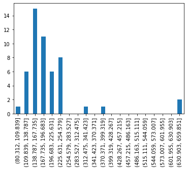

```python
effectif=pd.cut(prix_moyens,20)
effectif2=pd.value_counts(effectif)
effectif3=effectif2.reindex(effectif.categories)
effectif3.plot(kind='bar')
```

Et comme cela avec Numpy:

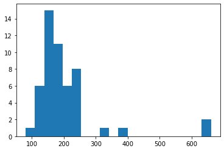

```python
plt.hist(prix_moyens,bins=20)
```

L'estimation de densité en pandas peut se faire ainsi

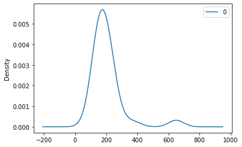

```python
effectif=pd.DataFrame(prix_moyens)
effectif.plot(kind='kde')
```

### Densité cumulée

**[Q]** **Calcul de la densité cumulée**

Calculer la densité cumulée à partir des prix moyens, avec un intervalle de discrétisation donné et la représenter graphiquement.

La méthode doit rendre deux tableaux: l'abscisse $X$ (les prix moyens possibles entre prix min et prix max), et la densité associée

**[Q]** **Quartiles**

Ecrire la fonction Q(alpha,x,y) qui permet de trouver le quartile(alpha,x,y).

- quartile(0.5,x,densite) correspondra à la médiane.

Calculer et représenter graphiquement le boxplot.

Remarque: un boxplot en pandas se fait ainsi:

```
a=pd.DataFrame(prix_moyens)
a.boxplot()
```

### Variance

**[Q]** **Calcul de variances**

On souhaite maintenant rajouter une colonne `HighQ_var` aux données originales contenant la variance des prix par état. Donner les intructions Python correspondantes.

**ATTENTION**, cela suppose de traiter les états (State) les uns après les autres...

```
State
Alabama                   2.370749
Alaska                   31.137567
Arizona                   4.063247
Arkansas                 47.141986
California                2.982686
Colorado                  6.356718
Connecticut              18.372574
Delaware                 24.827685
District of Columbia      3.976920
Florida                   5.258257
Georgia                  13.400555
Hawaii                    9.469260
Idaho                     0.840436
Illinois                  5.790658
Indiana                   3.453509
Iowa                      7.875726
Kansas                    3.951313
Kentucky                  1.074988
Louisiana                23.778186
Maine                    22.066151
Maryland                 34.891397
Massachusetts            12.740908
Michigan                 18.449891
Minnesota                79.051308
Mississippi               7.309370
Missouri                 54.772887
Montana                  10.967851
Nebraska                 30.419953
Nevada                    1.848997
New Hampshire            51.118775
New Jersey               12.833771
New Mexico                6.427070
New York                 12.245147
North Carolina           16.311250
North Dakota             55.694703
Ohio                      2.698508
Oklahoma                 31.829491
Oregon                    7.561688
Pennsylvania             12.866467
Rhode Island             44.814466
South Carolina           14.913978
South Dakota            138.362692
Tennessee                14.840045
Texas                    16.169573
Utah                      4.275242
Vermont                  12.881744
Virginia                 11.862465
Washington                1.347089
West Virginia             8.248240
Wisconsin                11.744638
Wyoming                 219.612495
Name: HighQ, dtype: float64
```

# Travail de synthèse : La Californie

Pandas permet de faire la synthèse de données de la manière suivante (pour le DataFrame de nom `df`):

```
df.describe()
```

**[Q]** Vérifier que les valeurs trouvées sur l'état de la Californie correspondent aux valeurs trouvées grâce à vos différentes fonctions.

Pour cela, donner dans ce qui suit le code qui utilise vos fonctions (moyennes, variance, et quartiles) ainsi que le résutlats de la fonction `describe`.

**[Q]** **Matrice de corrélation**

Nous allons maintenant nous intéresser à calculer la corrélation entre les prix à New York et les prix en Californie.

Commencer par représenter le nuage des points des prix (par date) en Californie (axe $X$) et à New York (axe $Y$) pour la bonne qualité.

Pour cela, on commence par créer un DataFrame avec ces informations:

```python
prix_ny=prices_pd[prices_pd['State']=='New York']
prix_ca=prices_pd[prices_pd['State']=='California']
prix_ca_ny=prix_ca.merge(prix_ny,on='date')
prix_ca_ny.head()

# Exécuter cette boîte et commenter le résultat obtenu
```

|  | State_x | HighQ_x | HighQN_x | MedQ_x | MedQN_x | LowQ_x | LowQN_x | date | State_y | HighQ_y | HighQN_y | MedQ_y | MedQN_y | LowQ_y | LowQN_y |
| --- | --- | --- | --- | --- | --- | --- | --- | --- | --- | --- | --- | --- | --- | --- | --- |
| 0 | California | 248.78 | 12096 | 193.56 | 12812 | 192.92 | 778 | 2014-01-01 | New York | 351.98 | 5800 | 268.88 | 5824 | 190.38 | 482 |
| 1 | California | 243.96 | 16512 | 189.35 | 19151 | NaN | 1096 | 2015-01-01 | New York | 343.80 | 7840 | 263.56 | 8716 | NaN | 616 |
| 2 | California | 248.20 | 12571 | 192.80 | 13406 | 191.94 | 804 | 2014-02-01 | New York | 352.35 | 6051 | 268.50 | 6115 | 190.16 | 497 |
| 3 | California | 243.30 | 16904 | 188.95 | 19764 | NaN | 1123 | 2015-02-01 | New York | 343.09 | 8058 | 262.93 | 9015 | NaN | 628 |
| 4 | California | 247.60 | 12988 | 192.97 | 13906 | 191.40 | 839 | 2014-03-01 | New York | 351.18 | 6209 | 267.69 | 6356 | 189.64 | 507 |

**[Q]** **Nuages de points*

Représenter graphiquement le nuage des points : voir http://matplotlib.org/examples/shapes_and_collections/scatter_demo.html

**[Q]** **Corrélations**

A l'aide de la fonction moyenne écrite précédemment, écrire une fonction `correlation(x,y)` qui calcule la corrélation lineaire entre deux tableaux Numpy.

```python
# Appliquer votre fonction avec l'instruction suivante:

# print("La correlation est :%f"%correlation(prix_ca_ny["HighQ_x"].values,prix_ca_ny["HighQ_y"].values))
```

**[Q]** **Matrice de corrélations**

Calculer la matrice des corrélations pour toutes les combinaisons d'états.

**[Q]** **D'autres corrélations...**

Calculer les correlations entre le prix (`low` et `high`) en fonction du revenu moyen par état disponible dans le tableau `demography_pd` chargé au début de cette feuille Jupyter.

Que peut-on en conclure ?

# Travail pour la fin de TME + Maison

Travail de rendu (à faire avant le prochain TP):

- Vous avez implémenté et vu comment calculer tout un ensemble d'indicateurs statistiques assez simples.
- Vous avez vu comment produire de jolis graphiques

## Travail à faire : proposez une analyse originale a l'aide des données disponibles ici : http://opendata.paris.fr et des indicateurs/graphiques vus en cours et aujourd'hui

- Voir http://matplotlib.org/gallery.html pour les visualisations

#### Exemple :

- (Récupération de données: ) Télécharger les données ici : https://opendata.paris.fr/explore/dataset/les-1000-titres-les-plus-reserves-dans-les-bibliotheques-de-pret/information/
- Calculer l'histogramme et la densité des différents titres
- Proposer une visualisation des 10 auteurs les plus demandés (en combinant leur ouvrages)
- ==> Proposer un nuage de mots contenus dans les titres à partir des données extraites (outil possible: https://www.jasondavies.com/wordcloud/ ou https://github.com/mbostock/d3/wiki/Gallery)